# Python 简易教程 (lecture for Solar Group)

## 简介

优势: 开源, 用户广, 用途广, 社区完善, 新手友好

https://www.jetbrains.com/research/python-developers-survey-2017/  
2017年的 python 使用调查报告 https://www.jetbrains.com/research/python-developers-survey-2017/

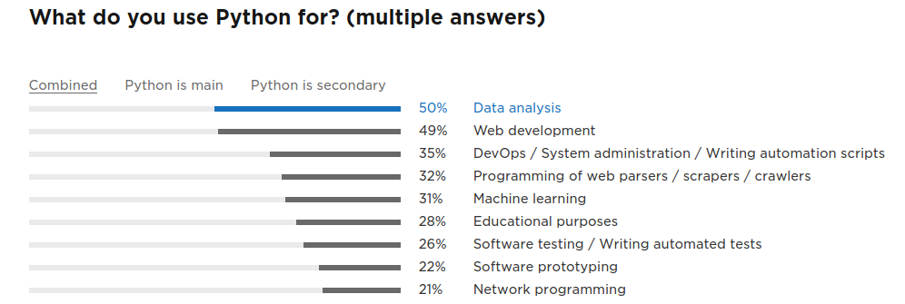

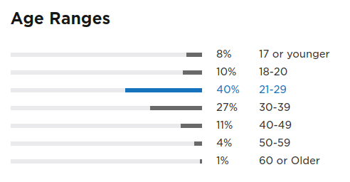

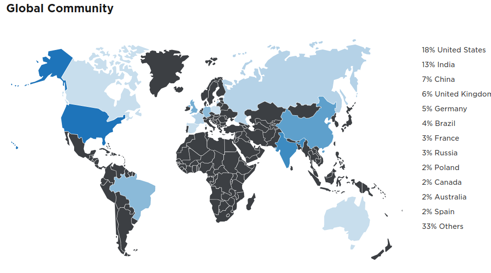

参考网站:

- 官方网站: https://www.python.org/
- stackoverflow https://stackoverflow.com/questions/tagged/python
- 官方文档 https://docs.python.org
- 廖雪峰的网站 (包含 python2.7 和 python3 的教程) https://www.liaoxuefeng.com
- wikibooks https://en.wikibooks.org/wiki/Python_Programming
- 演示代码执行过程的工具 http://pythontutor.com/
- 天文相关教程 (较新) https://python4astronomers.github.io

获取 python 包/模块/函数的帮助:

```
# python
>>> help(name)
```

```
# shell
$ pydoc <name>
$ pydoc -w <name>  # 生成一个 html 帮助文件
```

```
# ipython/jupyter
name?  # 弹出帮助文档, `Esc` 退出文档
```

## 基本语法

### 语法特点

- 对象编程的概念  
  类 -> 创建一个实例 -> 使用该实例所属的类下面的方法

  ```
  l = [3, 2, 1]  # l 是 list 的一个实例
  l.reverse()  # reverse 是一个方法(函数), reverse() 是一个实例
  l.__dir__()  # 查看 l 的所有方法(函数)
  ```

- 严格缩进(通常采用4个半角空格)

  ```
  if a > 0:
      a += 1
  print(a)
  ```

- 空格不敏感

  ```
  a + b * c ** 2 / d
  f (a, b)
  ```

- 大小写敏感, 使用大小写组合的变量名风格(下划线仍是合法变量名字符,但有特殊含义, 见 Python 进阶#脚本相关)

  ```
  from scipy.interpolate import BSpline
  ```

  ```
  import pandas as pd
  dataFrame = pd.DataFrame(array)
  ```

  见 IDL sav 文件读取
- 括号内换行不用换行符
- 单行注释 `# ...`
- 多行注释  
  函数或模块的开头的多行注释(将存储在`__doc__`变量), 可以用 `help()` 打印

  ```
  """
  这是一个
  多行注释
  """
  ```

- 同一行不同语句之间可用分号分隔

  ```
  x = 1; print(x)
  ```

- 列表和数组的索引默认从0开始
- 列表的最后一个元素可以加逗号

  ```
  [1, 2,]
  {'a' : 1, 'b' : 2,}
  ```

- *etc.*

### print函数

```python
a = 1.; b = 2.
```

```python
print('a=%.3f, b=%.1e' % (a, b))
```

```
a=1.000, b=2.0e+00
```

```python
print(f'a={a}, b={b:.3f}')
```

```
a=1.0, b=2.000
```

```python
%%python2
print('xxx'),
print('yyy')
```

```
xxx yyy
```

```python
%%python3
print('xxx', end=' ')
print('yyy')
```

```
xxx yyy
```

更多格式化参考 https://pyformat.info/

### 基本运算

运算符参考:  
https://en.wikibooks.org/wiki/Python_Programming/Basic_Math  
https://www.tutorialspoint.com/python/python_basic_operators.htm

```python
a = 1
a += 1  # 没有 a++ 这种语法
a
```

```
2
```

```python
3. ** 2  # 自动转换数据类型
```

```
9.0
```

```python
1 < 2 != 3  # 判断, 可以连写
```

```
True
```

```python
a = None
a is None  # 注意这时不用 `==`
```

```
True
```

### 字符串

用双引号和单引号皆可 (取决于所引内容).  
字符串具有和列表 (list) 类似的运算规则 (见之后的 list 说明):

```python
'a' * 10
```

```
'aaaaaaaaaa'
```

```python
'a' + 'b'
```

```
'ab'
```

```python
'abc'[0]
```

```
'a'
```

```python
print('\n')
```

```python
print(r'\n')  # same as '\\n'
```

```
\n
```

### list, tuple, dict, set

- 有序表 list, tuple

```python
l = [0, 1, 2, 3, 4, 5]  # list, 元素可变
t = (0, 1, 2, 3, 4, 5)  # tuple, 元素不可变
```

```python
l[0:3]  # 一个切片(slice)
```

```
[0, 1, 2]
```

```python
t[0:3]
```

```
(0, 1, 2)
```

```python
l[1:5:2]  # 索引: [start, stop, step] (结果不包含 stop)
```

```
[1, 3]
```

```python
l[5:1:-1]  # step < 0, 仍然不包含 stop (此例中 stop=1)
```

```
[5, 4, 3, 2]
```

list 常用运算

```python
l = [0, 1, 2, 3, 4, 5]
l.append('x')  # 添加在最后
print(l)
l.insert(3, 'y')  # 添加在 l[i] 之前
print(l)
print(l.pop(1))  # 删除某元素并返回该值
print(l)
```

```
[0, 1, 2, 3, 4, 5, 'x']
[0, 1, 2, 'y', 3, 4, 5, 'x']
1
[0, 2, 'y', 3, 4, 5, 'x']
```

```python
print(l * 2)  # 重复N遍
print(l + [6, 7])  # 合并两个list
```

[output not shown]

list 可以排序 (当元素为同一类型且可比较大小时), 返回到原列表

```python
l = ['b', 'a']
l.sort()
l
```

```
['a', 'b']
```

```python
l = [2, 1]
l.sort()
l
```

```
[1, 2]
```

- 字典 dict

```python
d = {'a' : 1, 'b' : 2}
```

```python
d = dict(a=1, b=2) # 注意这时没有引号
```

```python
d['a']
```

```
1
```

- 集合 set

```python
s = {3, 2, 1, 3}  # set, 将自动排序并去除重复, 常用于 for 循环
s  # 不能用 s[i] 来索引
```

```
{1, 2, 3}
```

set 不可索引, 但可用作 for 循环. 见 Python 进阶#迭代器

```python
for i in s:
    print(i)
```

```
1
2
3
```

```python
l2 = [i for i in s]
print(l2)
```

```
[1, 2, 3]
```

### if 语句

python 里没有 `case`, 只有 `if` (非零数值、非空字符串、非空 list 等皆为 True)

```
if <条件判断1>:
    <执行1>
elif <条件判断2>:
    <执行2>
elif <条件判断3>:
    <执行3>
else:
    <执行4>
```

### 相关工具

#### pip

[figure not shown]

> The **Python Package Index (PyPI)** is a repository of software for the Python programming language.  
> PyPI helps you find and install software developed and shared by the Python community.  
> https://pypi.org/

```
$ pip install <pkg_name>
```

(其他命令见 Python 安装和配置#用 pip 安装 python 包)

#### Anaconda

[figure not shown]

[figure not shown]

[figure not shown]

**Anaconda** (https://www.anaconda.com/)  
安装好的 conda 包含独立于系统的 python 版本, 一部分已编译好的包, pip 工具, 以及不同环境的子目录.  
可根据需要切换不同的 conda 环境以使用不同的 python 版本或不同的包的组合.

```
$ conda install <pkg_name>
```

其他命令见 Python 安装和配置#使用 conda 命令  
详细说明见 Python 进阶#Anaconda

#### IPython & Jupyter

[figure not shown]

```python
# Have a look (ipython)
!cd && gnome-terminal --window-with-profile='lydia_white'
!sleep 0.5 && xdotool type --delay 200 "ipython" && xdotool key Return
!sleep 3 && xdotool type --delay 200 "!idl" && xdotool key Return
!sleep 3 && xdotool key Ctrl+d
!sleep 1 && xdotool type --delay 200 "!csh -c sswidl" && xdotool key Return
```

http://jupyter.org/

[figure not shown]

https://nbviewer.jupyter.org/

[figure not shown]

参考文档 http://jupyter-notebook.readthedocs.io/en/stable/

- 打开 `jupyter notebook`:

```
$ jupyter notebook [filename]
```